# General Assembly Data Science Immersion Program

# Is This Mushroom Edible or Poisonous

# Executive Summary

## Approach

[figure not shown]

# Summary of Findings

# Recommendations for Next Steps

As with many exploritory projects, new approaches and potential applications come to mind. In this case, the task is to find the salient features needed to accurately, if possible, identify a mushroom as poisonous or not. A expansion of the scope of such an effort could be to identify the mushroom itself, with the side effect of knowing it's edibility. I believe that a rule-based expert systems approach may be better suited to the task. One could load up an expert system's working memory with known mushrooms and their attributes along with whatever is known regarding a new sample. The rules could be structured to find the best match given the known sample data and ask directed questions to the user to refine its prediction. In this way, new known mushrooms and their characteristics could be added at will to expand the range of identifiable mushrooms without having to change the underlying rule logic. The results of this current study could feed the selection of the critical features and characteristics to hone in on.

## Data Description

Sources: (a) Mushroom records drawn from The Audubon Society Field Guide to North American Mushrooms (1981). G. H. Lincoff (Pres.), New York: Alfred A. Knopf (b) Donor: Jeff Schlimmer (Jeffrey.Schlimmer@a.gp.cs.cmu.edu) (c) Date: 27 April 1987

Relevant Information: This data set includes descriptions of hypothetical samples corresponding to 23 species of gilled mushrooms in the Agaricus and Lepiota Family (pp. 500-525). Each species is identified as definitely edible, definitely poisonous, or of unknown edibility and not recommended. This latter class was combined with the poisonous one. The Guide clearly states that there is no simple rule for determining the edibility of a mushroom; no rule like ``leaflets three, let it be'' for Poisonous Oak and Ivy.

Number of Instances: 8124

Number of Attributes: 22 (all nominally valued)

Logical rules for the mushroom data sets.

[output not shown]

Attribute Information: (classes: edible=e, poisonous=p)

```
 1. cap-shape:                bell=b,conical=c,convex=x,flat=f,
                              knobbed=k,sunken=s
 2. cap-surface:              fibrous=f,grooves=g,scaly=y,smooth=s
 3. cap-color:                brown=n,buff=b,cinnamon=c,gray=g,green=r,
                              pink=p,purple=u,red=e,white=w,yellow=y
 4. bruises?:                 bruises=t,no=f
 5. odor:                     almond=a,anise=l,creosote=c,fishy=y,foul=f,
                              musty=m,none=n,pungent=p,spicy=s
 6. gill-attachment:          attached=a,descending=d,free=f,notched=n
 7. gill-spacing:             close=c,crowded=w,distant=d
 8. gill-size:                broad=b,narrow=n
 9. gill-color:               black=k,brown=n,buff=b,chocolate=h,gray=g,
                              green=r,orange=o,pink=p,purple=u,red=e,
                              white=w,yellow=y
10. stalk-shape:              enlarging=e,tapering=t
11. stalk-root:               bulbous=b,club=c,cup=u,equal=e,
                              rhizomorphs=z,rooted=r,missing=?
12. stalk-surface-above-ring: fibrous=f,scaly=y,silky=k,smooth=s
13. stalk-surface-below-ring: fibrous=f,scaly=y,silky=k,smooth=s
14. stalk-color-above-ring:   brown=n,buff=b,cinnamon=c,gray=g,orange=o,
                              pink=p,red=e,white=w,yellow=y
15. stalk-color-below-ring:   brown=n,buff=b,cinnamon=c,gray=g,orange=o,
                              pink=p,red=e,white=w,yellow=y
16. veil-type:                partial=p,universal=u
17. veil-color:               brown=n,orange=o,white=w,yellow=y
18. ring-number:              none=n,one=o,two=t
19. ring-type:                cobwebby=c,evanescent=e,flaring=f,large=l,
                              none=n,pendant=p,sheathing=s,zone=z
20. spore-print-color:        black=k,brown=n,buff=b,chocolate=h,green=r,
                              orange=o,purple=u,white=w,yellow=y
21. population:               abundant=a,clustered=c,numerous=n,
                              scattered=s,several=v,solitary=y
22. habitat:                  grasses=g,leaves=l,meadows=m,paths=p,
                              urban=u,waste=w,woods=d
```

## The Model

Datasets used for various models

```
* original            = clean copy of the original data for chain of custody purposes

* shrooms_rules_X     = 80% of training data for reduced dimensionality based on rule data
* shrooms_rules_y     = 80% of target data for reduced dimensionality based on rule data
* shrooms_rules_test  = 80% of testing data for reduced dimensionality based on rule data

* shrooms_scv_X       = 80% of training data
* shrooms_scv_y       = 80% of target data
* shrooms_scv_test    = 20 % of testing data

* shrooms_knn_X        80% of training data
* shrooms_knn_y       = 80% of target data
* shrooms_knn_test    = 20 % of testing data

* shrooms_scve_X      = 80% of training data
* shrooms_scve_y      = 80% of target data
* shrooms_scve_test   = 20 % of testing data
```

Models

- SCV Linear
  - shrooms_scv_X = 80% of training data
  - shrooms_scv_y = 80% of target data
  - shrooms_scv_test = 20 % of testing data
- kNN
  - shrooms_knn_X = 80% of training data
  - shrooms_knn_y = 80% of target data
  - shrooms_knn_test = 20 % of testing data
- SVC Ensemble (maybe)
  - shrooms_scve_X = 80% of training data
  - shrooms_scve_y = 80% of target data
  - shrooms_scve_test = 20 % of testing data

Feature Reduction (combination of)

- rule information given with data
- personal a priori knowledge
- PCA

For each model

#### The following block is used to import all Python libraries used in this model

```python
import numpy as np
import pandas as pd
import matplotlib as mpl
import seaborn as sns


from matplotlib import pyplot as plt
from sklearn.svm import SVC
from sklearn.cross_validation import cross_val_score
from sklearn.neighbors import KNeighborsClassifier
from sklearn.preprocessing import StandardScaler
from sklearn.decomposition import PCA as sklearnPCA

%matplotlib inline
```

[output not shown]

#### The following block imports the mushroom classification data stored in mushrooms.csv and stores it in a dataframe called **original**</b>. Each model will start with a copy of original and manipulate the data to suit the needs of the model. The original data will be preserved in the spirit of "chain of custody of evidence"

```python
original = pd.read_csv("mushrooms.csv") #original will be kept for historical purposes
```

We willl use a dataframe called shrooms to do some initial exploration of our data

```python
shrooms = original.copy()
# from sklearn.model_selection import train_test_split

# train, test = train_test_split(df, test_size = 0.2)
```

#### Let's take a look at some of the features of this data

```python
shrooms.head()
```

|  | class | cap-shape | cap-surface | cap-color | bruises | odor | gill-attachment | gill-spacing | gill-size | gill-color | ... | stalk-surface-below-ring | stalk-color-above-ring | stalk-color-below-ring | veil-type | veil-color | ring-number | ring-type | spore-print-color | population | habitat |
| --- | --- | --- | --- | --- | --- | --- | --- | --- | --- | --- | --- | --- | --- | --- | --- | --- | --- | --- | --- | --- | --- |
| 0 | p | x | s | n | t | p | f | c | n | k | ... | s | w | w | p | w | o | p | k | s | u |
| 1 | e | x | s | y | t | a | f | c | b | k | ... | s | w | w | p | w | o | p | n | n | g |
| 2 | e | b | s | w | t | l | f | c | b | n | ... | s | w | w | p | w | o | p | n | n | m |
| 3 | p | x | y | w | t | p | f | c | n | n | ... | s | w | w | p | w | o | p | k | s | u |
| 4 | e | x | s | g | f | n | f | w | b | k | ... | s | w | w | p | w | o | e | n | a | g |

5 rows × 23 columns

```python
shrooms.shape
```

```
(8124, 23)
```

```python
shrooms.columns
```

```
Index(['class', 'cap-shape', 'cap-surface', 'cap-color', 'bruises', 'odor',
       'gill-attachment', 'gill-spacing', 'gill-size', 'gill-color',
       'stalk-shape', 'stalk-root', 'stalk-surface-above-ring',
       'stalk-surface-below-ring', 'stalk-color-above-ring',
       'stalk-color-below-ring', 'veil-type', 'veil-color', 'ring-number',
       'ring-type', 'spore-print-color', 'population', 'habitat'],
      dtype='object')
```

[output not shown]

[figure not shown]

```python
corrmat = shrooms.corr()
f, ax = plt.subplots(figsize = (12,9))
sns.heatmap(corrmat, vmax = .8, square=True)
# networks = corrmat.columns.get_level_values("network")
# for i, network in enumerate(neworks):
#     if i and network != networks[i - 1]:
#         ax.axhline(len(networks) - i, c="w")
#         ax.axvline(i, c="w")
f.tight_layout()
```

```python
shrooms.describe()
```

[output not shown]

#### The data is encoded as an alpha character which maps to an attribute as described in the Data Description section above. Let's convert those alpha characters to dummy columns in order to start looking for correlations.

```python
shrooms.columns
```

```python
columns = shrooms.columns
columns = columns.drop('class') # we won't make dummy columns for our target column
for col in columns:
    for data in shrooms[col].unique():
        shrooms[col + "_" + data] = shrooms[col] == data

# we can now drop the original columns
for col in columns:
    shrooms.drop(col, inplace = True, axis = 1)
```

```python
shrooms.head(20)
```

|  | class | cap-shape_x | cap-shape_b | cap-shape_s | cap-shape_f | cap-shape_k | cap-shape_c | cap-surface_s | cap-surface_y | cap-surface_f | ... | population_v | population_y | population_c | habitat_u | habitat_g | habitat_m | habitat_d | habitat_p | habitat_w | habitat_l |
| --- | --- | --- | --- | --- | --- | --- | --- | --- | --- | --- | --- | --- | --- | --- | --- | --- | --- | --- | --- | --- | --- |
| 0 | p | True | False | False | False | False | False | True | False | False | ... | False | False | False | True | False | False | False | False | False | False |
| 1 | e | True | False | False | False | False | False | True | False | False | ... | False | False | False | False | True | False | False | False | False | False |
| 2 | e | False | True | False | False | False | False | True | False | False | ... | False | False | False | False | False | True | False | False | False | False |
| 3 | p | True | False | False | False | False | False | False | True | False | ... | False | False | False | True | False | False | False | False | False | False |
| 4 | e | True | False | False | False | False | False | True | False | False | ... | False | False | False | False | True | False | False | False | False | False |
| 5 | e | True | False | False | False | False | False | False | True | False | ... | False | False | False | False | True | False | False | False | False | False |
| 6 | e | False | True | False | False | False | False | True | False | False | ... | False | False | False | False | False | True | False | False | False | False |
| 7 | e | False | True | False | False | False | False | False | True | False | ... | False | False | False | False | False | True | False | False | False | False |
| 8 | p | True | False | False | False | False | False | False | True | False | ... | True | False | False | False | True | False | False | False | False | False |
| 9 | e | False | True | False | False | False | False | True | False | False | ... | False | False | False | False | False | True | False | False | False | False |
| 10 | e | True | False | False | False | False | False | False | True | False | ... | False | False | False | False | True | False | False | False | False | False |
| 11 | e | True | False | False | False | False | False | False | True | False | ... | False | False | False | False | False | True | False | False | False | False |
| 12 | e | False | True | False | False | False | False | True | False | False | ... | False | False | False | False | True | False | False | False | False | False |
| 13 | p | True | False | False | False | False | False | False | True | False | ... | True | False | False | True | False | False | False | False | False | False |
| 14 | e | True | False | False | False | False | False | False | False | True | ... | False | False | False | False | True | False | False | False | False | False |
| 15 | e | False | False | True | False | False | False | False | False | True | ... | False | True | False | True | False | False | False | False | False | False |
| 16 | e | False | False | False | True | False | False | False | False | True | ... | False | False | False | False | True | False | False | False | False | False |
| 17 | p | True | False | False | False | False | False | True | False | False | ... | False | False | False | False | True | False | False | False | False | False |
| 18 | p | True | False | False | False | False | False | False | True | False | ... | False | False | False | True | False | False | False | False | False | False |
| 19 | p | True | False | False | False | False | False | True | False | False | ... | False | False | False | True | False | False | False | False | False | False |

20 rows × 118 columns

```python
# and now let's declare that in our target variable 'class' that p=1 (poisonous) and e=0 (edible)
# and convert the data in y accordingly

shrooms['class'] = shrooms['class'] == 'p'
```

```python
shrooms.head()
```

|  | class | cap-shape_x | cap-shape_b | cap-shape_s | cap-shape_f | cap-shape_k | cap-shape_c | cap-surface_s | cap-surface_y | cap-surface_f | ... | population_v | population_y | population_c | habitat_u | habitat_g | habitat_m | habitat_d | habitat_p | habitat_w | habitat_l |
| --- | --- | --- | --- | --- | --- | --- | --- | --- | --- | --- | --- | --- | --- | --- | --- | --- | --- | --- | --- | --- | --- |
| 0 | True | True | False | False | False | False | False | True | False | False | ... | False | False | False | True | False | False | False | False | False | False |
| 1 | False | True | False | False | False | False | False | True | False | False | ... | False | False | False | False | True | False | False | False | False | False |
| 2 | False | False | True | False | False | False | False | True | False | False | ... | False | False | False | False | False | True | False | False | False | False |
| 3 | True | True | False | False | False | False | False | False | True | False | ... | False | False | False | True | False | False | False | False | False | False |
| 4 | False | True | False | False | False | False | False | True | False | False | ... | False | False | False | False | True | False | False | False | False | False |

5 rows × 118 columns

```python
# Now let's replace all of the bool values (True/False) with integers (1/0)
# columns = shrooms.columns
# for col in columns:
#     print(col)
#     shrooms[col] = shrooms[col].astype(int)
shrooms = shrooms.astype(int)
```

```python
shrooms.head()
```

|  | class | cap-shape_x | cap-shape_b | cap-shape_s | cap-shape_f | cap-shape_k | cap-shape_c | cap-surface_s | cap-surface_y | cap-surface_f | ... | population_v | population_y | population_c | habitat_u | habitat_g | habitat_m | habitat_d | habitat_p | habitat_w | habitat_l |
| --- | --- | --- | --- | --- | --- | --- | --- | --- | --- | --- | --- | --- | --- | --- | --- | --- | --- | --- | --- | --- | --- |
| 0 | 1 | 1 | 0 | 0 | 0 | 0 | 0 | 1 | 0 | 0 | ... | 0 | 0 | 0 | 1 | 0 | 0 | 0 | 0 | 0 | 0 |
| 1 | 0 | 1 | 0 | 0 | 0 | 0 | 0 | 1 | 0 | 0 | ... | 0 | 0 | 0 | 0 | 1 | 0 | 0 | 0 | 0 | 0 |
| 2 | 0 | 0 | 1 | 0 | 0 | 0 | 0 | 1 | 0 | 0 | ... | 0 | 0 | 0 | 0 | 0 | 1 | 0 | 0 | 0 | 0 |
| 3 | 1 | 1 | 0 | 0 | 0 | 0 | 0 | 0 | 1 | 0 | ... | 0 | 0 | 0 | 1 | 0 | 0 | 0 | 0 | 0 | 0 |
| 4 | 0 | 1 | 0 | 0 | 0 | 0 | 0 | 1 | 0 | 0 | ... | 0 | 0 | 0 | 0 | 1 | 0 | 0 | 0 | 0 | 0 |

5 rows × 118 columns

#### Let's do a heatmap of a correlation matrix of all of these characteristics to see if there is anything striking.

```python
corrmat = shrooms.corr()
```

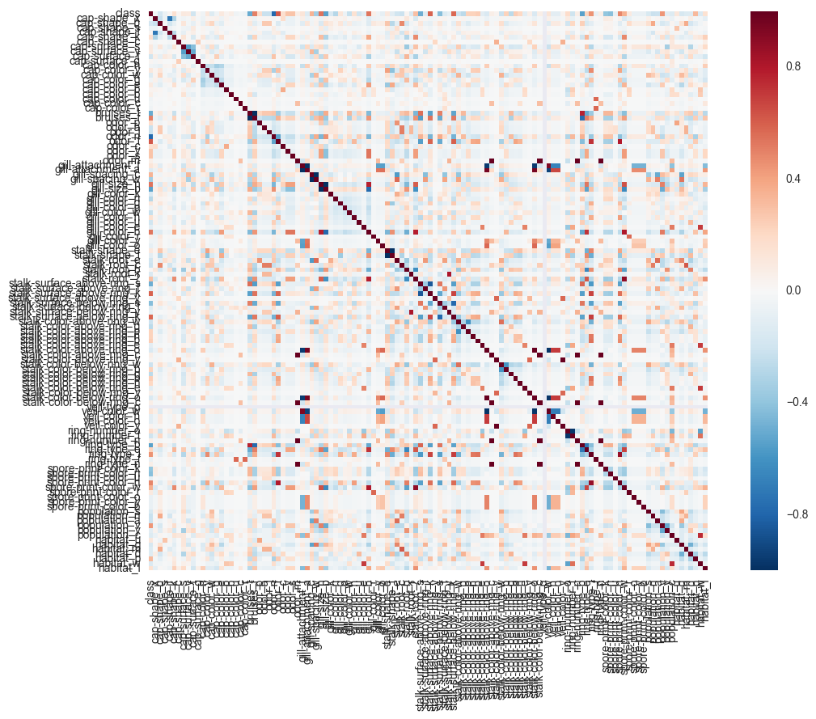

```python
f, ax = plt.subplots(figsize = (12,9))
sns.heatmap(corrmat, vmax = .8, square=True)
# networks = corrmat.columns.get_level_values("network")
# for i, network in enumerate(neworks):
#     if i and network != networks[i - 1]:
#         ax.axhline(len(networks) - i, c="w")
#         ax.axvline(i, c="w")
f.tight_layout()
```

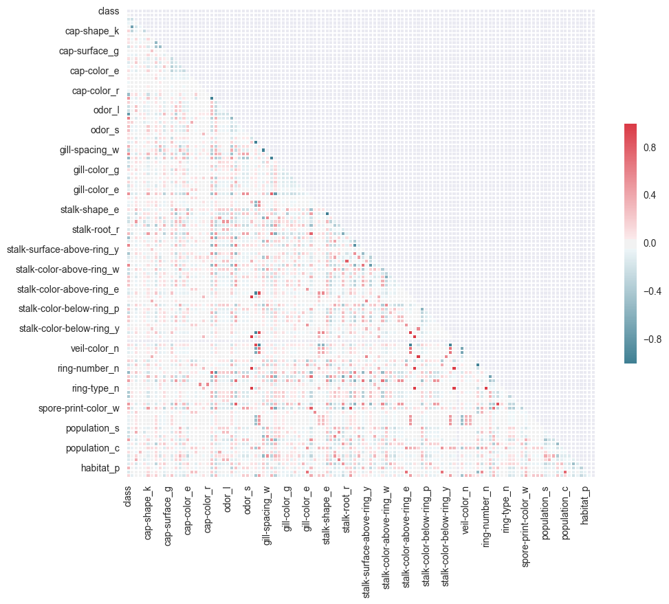

```python
# Generate a mask for the upper triangle
mask = np.zeros_like(corrmat, dtype=np.bool)
mask[np.triu_indices_from(mask)] = True

# Set up the matplotlib figure
f, ax = plt.subplots(figsize=(11, 9))

# Generate a custom diverging colormap
cmap = sns.diverging_palette(220, 10, as_cmap=True)

# Draw the heatmap with the mask and correct aspect ratio
sns.heatmap(corrmat, mask=mask, cmap=cmap, vmax=.3,
            square=True, xticklabels=5, yticklabels=5,
            linewidths=.5, cbar_kws={"shrink": .5}, ax=ax)
```

#### Let's see if we can find anything interesting about the attributes using a Support Vector Machine

```python
#first let's separate the training (X) from the target (y) data
X = shrooms.drop('class', axis=1)
y = shrooms['class']
```

```python
model = SVC(kernel='linear')
model.fit(X, y)
SVC(C=1.0, cache_size=200, class_weight=None, coef0=0.0,
  decision_function_shape=None, degree=3, gamma='auto', kernel='linear',
  max_iter=-1, probability=False, random_state=None, shrinking=True,
  tol=0.001, verbose=False)
```

```
SVC(C=1.0, cache_size=200, class_weight=None, coef0=0.0,
  decision_function_shape=None, degree=3, gamma='auto', kernel='linear',
  max_iter=-1, probability=False, random_state=None, shrinking=True,
  tol=0.001, verbose=False)
```

#### Cross Validation

```python
for i in range(2, 8):
    cvscores = cross_val_score(model, X, y, cv = i, n_jobs=-1)
    print ("CV score: ", cvscores.mean(), " +/- ", cvscores.std(), " cv = ", i)
```

```
CV score:  0.788281634663  +/-  0.0226489414082  cv =  2
CV score:  0.895094448406  +/-  0.127065203692  cv =  3
CV score:  0.898572131955  +/-  0.160155227987  cv =  4
CV score:  0.944108059307  +/-  0.0785792971034  cv =  5
CV score:  0.957648303756  +/-  0.0627803433673  cv =  6
CV score:  0.95766259973  +/-  0.0699590934167  cv =  7
```

#### Grid Search

```python
from sklearn.grid_search import GridSearchCV
parameters = {'kernel':('linear', 'rbf'), 'C':[0.1, 1, 3, 10]}
clf = GridSearchCV(model, parameters, n_jobs=-1)
clf.fit(X, y)
clf.best_estimator_
```

```
C:\Program Files\Anaconda3\lib\site-packages\sklearn\grid_search.py:43: DeprecationWarning: This module was deprecated in version 0.18 in favor of the model_selection module into which all the refactored classes and functions are moved. This module will be removed in 0.20.
  DeprecationWarning)
```

```
SVC(C=1, cache_size=200, class_weight=None, coef0=0.0,
  decision_function_shape=None, degree=3, gamma='auto', kernel='linear',
  max_iter=-1, probability=False, random_state=None, shrinking=True,
  tol=0.001, verbose=False)
```

#### KNN

```python
knn = KNeighborsClassifier(n_neighbors=5,
                           weights='uniform',
                           p=2,
                           metric='minkowski')
```

```python
accuracies = cross_val_score(knn, X, y, cv=5)

print("K-Fold accuracies:", accuracies)
print("Mean accuracy:", accuracies.mean())
```

```
K-Fold accuracies: [ 0.84686347  1.          0.99569231  1.          0.65763547]
Mean accuracy: 0.900038248861
```

```python
shrooms_cat = original.copy()
```

```python
columns_cat = shrooms_cat.columns
```

```python
for col in columns_cat:
    shrooms_cat[col] = shrooms_cat[col].astype("category")
    shrooms_cat[col] = shrooms_cat[col].cat.codes
shrooms_cat.head()
```

|  | class | cap-shape | cap-surface | cap-color | bruises | odor | gill-attachment | gill-spacing | gill-size | gill-color | ... | stalk-surface-below-ring | stalk-color-above-ring | stalk-color-below-ring | veil-type | veil-color | ring-number | ring-type | spore-print-color | population | habitat |
| --- | --- | --- | --- | --- | --- | --- | --- | --- | --- | --- | --- | --- | --- | --- | --- | --- | --- | --- | --- | --- | --- |
| 0 | 1 | 5 | 2 | 4 | 1 | 6 | 1 | 0 | 1 | 4 | ... | 2 | 7 | 7 | 0 | 2 | 1 | 4 | 2 | 3 | 5 |
| 1 | 0 | 5 | 2 | 9 | 1 | 0 | 1 | 0 | 0 | 4 | ... | 2 | 7 | 7 | 0 | 2 | 1 | 4 | 3 | 2 | 1 |
| 2 | 0 | 0 | 2 | 8 | 1 | 3 | 1 | 0 | 0 | 5 | ... | 2 | 7 | 7 | 0 | 2 | 1 | 4 | 3 | 2 | 3 |
| 3 | 1 | 5 | 3 | 8 | 1 | 6 | 1 | 0 | 1 | 5 | ... | 2 | 7 | 7 | 0 | 2 | 1 | 4 | 2 | 3 | 5 |
| 4 | 0 | 5 | 2 | 3 | 0 | 5 | 1 | 1 | 0 | 4 | ... | 2 | 7 | 7 | 0 | 2 | 1 | 0 | 3 | 0 | 1 |

5 rows × 23 columns

```python
X = shrooms_cat.drop('class', axis = 1)
y = shrooms_cat['class']
```

#### histogram

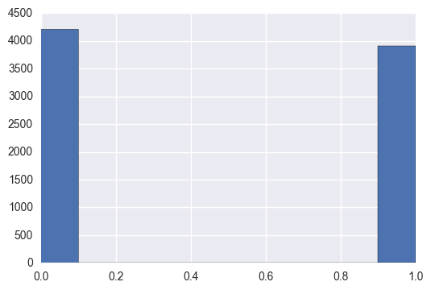

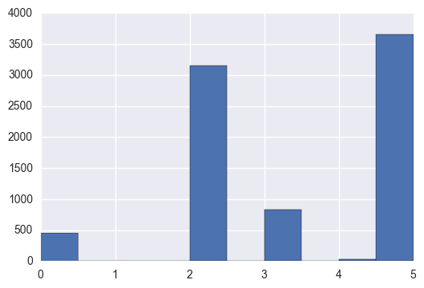

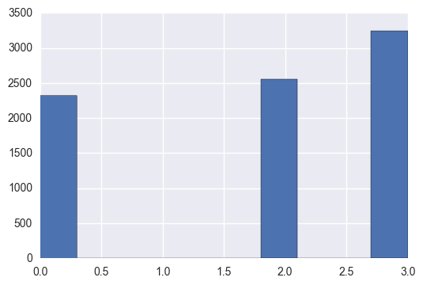

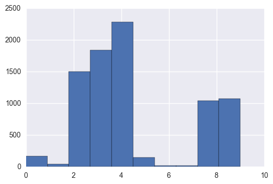

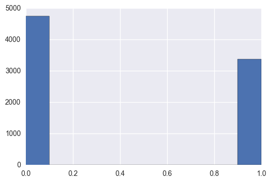

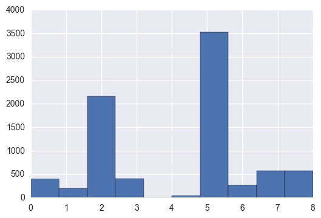

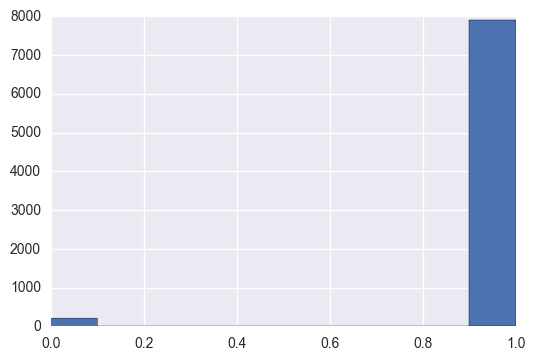

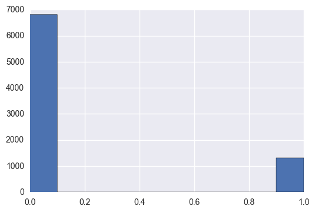

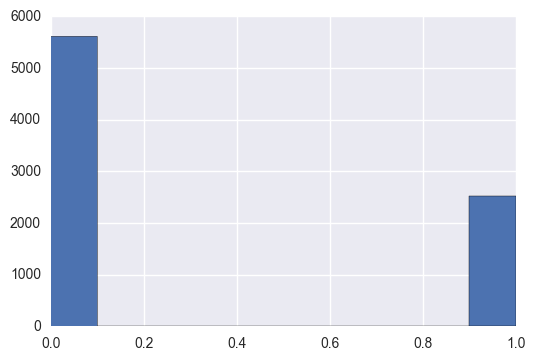

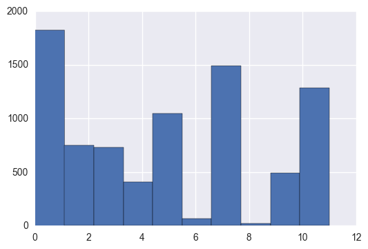

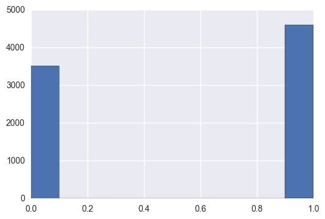

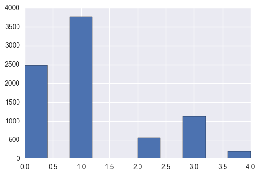

[11 more figures not shown]

```python
for col in shrooms_cat.columns:
    shrooms_cat[col].hist()
    plt.show()
```

```python
shrooms_cat.columns
```

```
Index(['class', 'cap-shape', 'cap-surface', 'cap-color', 'bruises', 'odor',
       'gill-attachment', 'gill-spacing', 'gill-size', 'gill-color',
       'stalk-shape', 'stalk-root', 'stalk-surface-above-ring',
       'stalk-surface-below-ring', 'stalk-color-above-ring',
       'stalk-color-below-ring', 'veil-type', 'veil-color', 'ring-number',
       'ring-type', 'spore-print-color', 'population', 'habitat'],
      dtype='object')
```